# HTE

> Note: Press the button on the upper right of this file to show all codes

# 1 Data preparation

First, load dataset and clean data as necessary.

```r
## read and create subsets
cope_subset <- read_csv("data/cope_subset.csv")
cope_subset %>% datatable(
  rownames = FALSE,
  options = list(
    pageLength = 5,
    columnDefs = list(list(className = 'dt-center',
                      targets = 0:4))))
```

| b_response_id | condition | b_cdi_mean | f1_cdi_mean | b_dem_sex | b_dem_orientation | b_dem_language | b_screener_age | b_dem_race_american_indian_or_alaska_native | b_dem_race_asian_including_asian_desi | b_dem_race_hispanic_latinx | b_dem_race_native_hawaiian_or_other_pacific_islander | b_dem_race_white_caucasian_non_hispanic_includes_middle_eastern | b_dem_race_black_african_american | b_covid_family_family_did_not_enough_enough_money_for_food | b_covid_family_family_did_not_have_a_regular_place_to_sleep_or_stay | b_covid_family_i_could_not_attend_school_in_person | b_covid_family_i_could_not_attend_school_at_all | b_covid_family_other | b_covid_family_family_did_not_have_enough_money_for_gas_transportation | b_covid_family_family_did_not_have_enough_money_to_pay_rent | b_covid_family_the_covid_19_pandemic_has_not_affected_me_or_my_family_in_these_ways_in_the_past_2_weeks | b_covid_cope_1_connecting_with_others | b_covid_cope_1_including_talking_with_people_you_trust_about_your_concerns_and_how_you_are_feeling | b_covid_cope_1_contacting_a_healthcare_provider | b_covid_cope_1_drinking_alcohol | b_covid_cope_1_smoking_more_cigarettes_or_vaping_more | b_dem_gender_agender | b_dem_gender_not_sure | b_dem_gender_other_please_specify | … |
| --- | --- | --- | --- | --- | --- | --- | --- | --- | --- | --- | --- | --- | --- | --- | --- | --- | --- | --- | --- | --- | --- | --- | --- | --- | --- | --- | --- | --- | --- | --- |
| R_02uyQw7i0v8yQRX | Placebo Control | 1.41666666666667 | 1 | Female | Pansexual | English | 14 | 0 | 0 | 0 | 0 | 1 | 0 | 1 | 0 | 1 | 1 | 1 | 0 | 0 | 0 | 1 | 1 | 0 | 0 | 0 | 0 | 0 | 0 | … |
| R_06bZX04ieGtQOWJ | Project Personality | 0.916666666666667 | 0.583333333333333 | Female | Other/Not listed (please specify) | English | 15 | 0 | 0 | 0 | 0 | 1 | 0 | 1 | 0 | 1 | 0 | 0 | 1 | 1 | 0 | 1 | 1 | 1 | 0 | 0 | 0 | 0 | 1 | … |
| R_089oJuXofDsITq9 | Placebo Control | 1.16666666666667 | 0.583333333333333 | Female | Gay/Lesbian/Homosexual | English | 16 | 0 | 0 | 0 | 0 | 1 | 0 | 0 | 0 | 0 | 0 | 0 | 0 | 0 | 1 | 1 | 1 | 0 | 0 | 0 | 0 | 0 | 0 | … |
| R_08lyOxzUAzbJqcV | Placebo Control | 1.33333333333333 | 1.41666666666667 | Female | Bisexual | English | 15 | 0 | 0 | 0 | 0 | 1 | 0 | 0 | 0 | 1 | 0 | 0 | 0 | 0 | 0 | 0 | 0 | 1 | 0 | 0 | 0 | 0 | 0 | … |
| R_0dEHbvY9Gs3dYSB | Project Personality | 0.916666666666667 | 0.5 | Female | Bisexual | English | 16 | 0 | 0 | 0 | 0 | 1 | 0 | 0 | 0 | 1 | 0 | 0 | 0 | 0 | 0 | 1 | 1 | 0 | 0 | 1 | 0 | 0 | 0 | … |
| R_0e2bSxAqehpqMiR | Project Personality | 1 | 0.666666666666667 | Female | Bisexual | English | 16 | 0 | 0 | 0 | 0 | 1 | 0 | 0 | 0 | 1 | 0 | 0 | 0 | 0 | 0 | 0 | 0 | 1 | 0 | 0 | 0 | 0 | 0 | … |
| R_0lDh6r7xrSRAemR | Project ABC | 1 | 0.833333333333333 | Female | Heterosexual/Straight | English | 14 | 0 | 1 | 0 | 0 | 0 | 0 | 0 | 0 | 1 | 0 | 0 | 0 | 0 | 0 | 0 | 0 | 0 | 0 | 0 | 0 | 0 | 0 | … |
| R_0MWZlutLcSpTEpH | Project Personality | 1.33333333333333 | 1.08333333333333 | Female | Bisexual | English | 16 | 0 | 1 | 0 | 0 | 0 | 0 | 0 | 0 | 1 | 0 | 0 | 0 | 0 | 0 | 0 | 0 | 0 | 0 | 0 | 0 | 0 | 0 | … |
| R_0NSaH6AKKJieJ4R | Placebo Control | 0.916666666666667 | 0.583333333333333 | Female | Heterosexual/Straight | English | 16 | 0 | 0 | 0 | 0 | 1 | 0 | 0 | 0 | 1 | 0 | 0 | 0 | 0 | 0 | 0 | 0 | 0 | 0 | 0 | 0 | 0 | 0 | … |
| R_0Ps1epuV8JY3Wcp | Placebo Control | 1.08333333333333 | 1 | Female | Pansexual | English | 14 | 0 | 0 | 1 | 0 | 0 | 1 | 0 | 0 | 1 | 0 | 0 | 0 | 1 | 0 | 0 | 0 | 0 | 0 | 0 | 0 | 0 | 0 | … |

[output cut: 1491 more lines]

```r
## gender identity subset
dem_gender_subset <- cope_subset %>% dplyr::select(starts_with("b_dem_gender"))

## coping strategies

dem_cope_subset <- cope_subset %>% dplyr::select(starts_with("b_covid_cope"))

## family challenges

dem_family_subset <- cope_subset %>% dplyr::select(starts_with("b_covid_family"))

## race

dem_race_subset <- cope_subset %>% dplyr::select(starts_with("b_dem_race"))

## sexual orientation

dem_orient_subset <- cope_subset %>% dplyr::select(b_dem_orientation)

## coping strategy subset
dem_cope_subset <- dem_cope_subset %>%
  dplyr::select(-"b_covid_cope_1_including_talking_with_people_you_trust_about_your_concerns_and_how_you_are_feeling")
```

## 1.1 Collapse categories

Re-code `sexual orientation`, `race`, `family challenge` variables by collapsing some categories with limited number of samples, and generating composite categories.

#### 1.1.0.1 Recode sexual orientation

```r
## recode sexual orientation
recode_orient_dat <- dem_orient_subset %>%
mutate(recod_orient= case_when(
  b_dem_orientation %in% c("Asexual", "I do not use a label", "Other/Not listed (please specify)") ~ "Other",
  b_dem_orientation %in% c("Gay/Lesbian/Homosexual", "Queer", "Unsure/Questioning") ~ "LGBTQ",
  b_dem_orientation %in% c("Bisexual", "Pansexual") ~ "LGBTQ",
  b_dem_orientation == "Heterosexual/Straight" ~ "Heterosexual",
  TRUE ~ b_dem_orientation
))
```

#### 1.1.0.2 Recode family challenges

```r
## recode family challenge
### number of challenges
challenge_num_dat <- dem_family_subset %>%
  mutate(challenge_num = apply(., 1, sum)) %>%
  mutate(challenge_num = ifelse(b_covid_family_the_covid_19_pandemic_has_not_affected_me_or_my_family_in_these_ways_in_the_past_2_weeks=="1",0,challenge_num)) %>%
  mutate(challenge_num3 = ifelse(challenge_num>=2, 2, challenge_num))

### category of challenges
challenge_cat_dat <-  dem_family_subset %>%
  mutate(challenge_cat = case_when(
    b_covid_family_family_did_not_enough_enough_money_for_food == 1 |
      b_covid_family_family_did_not_have_enough_money_for_gas_transportation == 1 |
      b_covid_family_family_did_not_have_a_regular_place_to_sleep_or_stay==1 |
      b_covid_family_family_did_not_have_enough_money_to_pay_rent == 1 ~ "Financial",

    b_covid_family_i_could_not_attend_school_in_person == 1 |
      b_covid_family_i_could_not_attend_school_at_all == 1 ~ "School",

    b_covid_family_other == 1 ~ "Other",

    b_covid_family_the_covid_19_pandemic_has_not_affected_me_or_my_family_in_these_ways_in_the_past_2_weeks == 1 ~ "No impact",

    TRUE ~ "No"
  ))


challenge_cat_dat <- dem_family_subset %>%
  mutate(
    Financial = b_covid_family_family_did_not_enough_enough_money_for_food == 1 |
      b_covid_family_family_did_not_have_enough_money_for_gas_transportation == 1 |
      b_covid_family_family_did_not_have_a_regular_place_to_sleep_or_stay == 1 |
      b_covid_family_family_did_not_have_enough_money_to_pay_rent == 1,

    School = b_covid_family_i_could_not_attend_school_in_person == 1 |
      b_covid_family_i_could_not_attend_school_at_all == 1,

    Other = b_covid_family_other == 1,

    No_impact = b_covid_family_the_covid_19_pandemic_has_not_affected_me_or_my_family_in_these_ways_in_the_past_2_weeks == 1,

    challenge_cat = case_when(
      Financial & School & Other ~ "Other",
      Financial & School ~ "Other",
      Financial & Other ~ "Other",
      School & Other ~ "Other",
      Financial ~ "Other",
      School ~ "School",
      Other ~ "Other",
      No_impact ~ "No impact",
      TRUE ~ "No challenge"
    )
  ) %>%
  dplyr::select(-Financial, -School, -Other, -No_impact)
```

#### 1.1.0.3 Recode race

```r
## identify all race patterns
race_pattern_dat <- cope_subset %>%
  dplyr::select(starts_with("b_dem_race")) %>%
  mutate(race_pattern = apply(., 1, function(row) paste0(row, collapse = "")))

cope_subset1 <- cope_subset %>%
  mutate(race_pattern =race_pattern_dat$race_pattern ) %>%
  ## recode race
  mutate(recode_race = case_when(
    race_pattern == "000010" ~ 'White',
    race_pattern == "000001" ~ 'Black/African-American',
    race_pattern == "010000" ~ 'Asian Including Asian Desi',
    race_pattern == "001000" ~ 'Hispanic/Latinx',
    race_pattern == "000000" ~ 'Prefer not to answer',
    TRUE ~ 'Mixed'
  )) %>%
  ## recode sexual orientation
  mutate(recode_orient = recode_orient_dat$recod_orient) %>%

  dplyr::select(-race_pattern) %>%
  ## recode language
  mutate(recode_language = case_when(
    b_dem_language == "English" ~ 'English',
    TRUE ~ 'Other'
  )) %>%
  ## reorder variables
  dplyr::select(-b_dem_language,-starts_with("b_dem_race")) %>%
  dplyr::select(recode_race,starts_with("b_dem_gender"),b_screener_age,b_dem_sex,b_dem_orientation,
         starts_with("b_covid_family"), starts_with("b_covid_cope"),recode_language, everything()
         )
```

## 1.2 Latent Class Analysis(LCA)

Apply LCA to find the latent class variables for `gender identity` and `coping strategies`, respectively.

### 1.2.1 Gender identity

```r
## Gender identity
tmp <- dem_gender_subset%>%
  mutate(gender_pattern = apply(., 1, function(row) paste0(row, collapse = "")))

## check patterns
tmp1 <- tmp$gender_pattern %>% table() %>% data.frame()

genderid_dat <- dem_gender_subset

## check correlation
genderid_dat_cor <- cor(genderid_dat) %>% data.frame


# The transgender indicator and gender_expansive indicator variables are removed because these two variables are the
# composite variables of other indicators


### correlation matrix
#genderid_dat_cor_melted <- melt(as.matrix(genderid_dat_cor))


# ggplot(data = genderid_dat_cor_melted, aes(x=Var1, y=Var2, fill=value)) +
#   geom_tile(color = "white") +
#   scale_fill_gradient2(low = "blue", high = "red", mid = "white",
#                        midpoint = 0, limit = c(-1, 1), space = "Lab",
#                        name="Correlation") +
#   theme_minimal() +
#   theme(axis.text.x = element_text(angle = 45, vjust = 1,
#                                    size = 12, hjust = 1)) +
#   coord_fixed() +
#   labs(x = "", y = "") +
#   ggtitle("Correlation Matrix Heatmap")

## prepare input data for poLCA

## only accept indicator variables coded start from 1 (transfer 01 --> 12)
recode_variables <- function(df) {
  df <- df %>% mutate(across(everything(), ~ as.integer(as.factor(.))))
  return(df)
}


## input of the poLCA
genderid_dat_LCA <- genderid_dat %>%
  recode_variables() %>%
  rename_with(~ str_remove(., "b_dem_gender_"), starts_with("b_dem_gender_"))

## define the indicator variables of LCA model
f1 <- cbind(
  agender, not_sure, other_please_specify,
  androgynous, nonbinary, two_spirited,
  female_to_male_transgender_ftm, trans_female_trans_feminine,
  trans_male_trans_masculine,
  # gender_expansive, ## composite removed
  third_gender, genderqueer, male_to_female_transgender_mtf,
  man_boy,
  # transgender, ## composite removed
  woman_girl) ~ 1

set.seed(1017)
gender_LCA2 <- poLCA(f1, data = genderid_dat_LCA,
              nclass = 2)


gender_LCA3 <- poLCA(f1, data = genderid_dat_LCA,
              nclass = 3)

gender_LCA4 <- poLCA(f1, data = genderid_dat_LCA,
              nclass = 4)


gender_LCA5 <- poLCA(f1, data = genderid_dat_LCA,
              nclass = 5)


gender_models <- list(gender_LCA2, gender_LCA3, gender_LCA4, gender_LCA5)
gender_model_stats <- data.frame(
  Model = 2:5,
  G2 = sapply(gender_models, function(x) x$Gsq),
  AIC = sapply(gender_models, function(x) x$aic),
  BIC = sapply(gender_models, function(x) x$bic)
)
```

#### 1.2.1.1 Step 1: LCA model selection

Compare LCA models for different number of classes.

the LCA model with 3 latent classes has comparable $G^2$, AIC, BIC. (could also use scree plot). therefore, a model with **3 latent class** is selected for gender identity.

```r
kable(gender_model_stats, caption = "Model Comparison for Different Number of Classes (Gender Identity variable)")
```

Table 1.1: Model Comparison for Different Number of Classes (Gender Identity variable)

| Model | G2 | AIC | BIC |
| --- | --- | --- | --- |
| 2 | 1348.0556 | 7529.195 | 7683.297 |
| 3 | 924.7536 | 7135.893 | 7369.704 |
| 4 | 821.6347 | 7062.774 | 7376.293 |
| 5 | 616.5568 | 6887.696 | 7280.923 |

#### 1.2.1.2 Step 2: classification error: averaged posterior probability(APP)

print APP, results suggest low classification error(APP>0.7).

```r
posterior_probs <- gender_LCA3$posterior

assigned_class <- apply(posterior_probs, 1, which.max)

mean_posterior_by_class <- numeric(ncol(posterior_probs))

for (k in 1:ncol(posterior_probs)) {
  mean_posterior_by_class[k] <- mean(posterior_probs[assigned_class == k, k])
}

print(mean_posterior_by_class)
```

```
## [1] 0.9648380 0.9863283 0.9650341
```

#### 1.2.1.3 Step 3: Final latent class probabilities

The probability of belonging to a specific class is calculated for each individual, and each individual is classified to a specific class based on the max. posterior probability. Below is the results of the posterior probabilities for all subjects (prob. of being in class $j$).

```r
## get predicted class (gender identity)
genderid_class <- gender_LCA3$predclass
genderid_predprob <- gender_LCA3$posterior
colnames(genderid_predprob) <- paste0("Class",c(1:3))
genderid_predprob %>% datatable(
  rownames = FALSE,
  options = list(
     pageLength = 5,
    columnDefs = list(list(className = 'dt-center',
                      targets = 0:2))))
```

| Class1 | Class2 | Class3 |
| --- | --- | --- |
| 0.9217492679152807 | 0 | 0.07825073208471933 |
| 0.9983647405473743 | 2.495581721229972e-52 | 0.00163525945262557 |
| 0.004283089340769337 | 0.9957169106592306 | 2.142905259001684e-50 |
| 0.004283089340769337 | 0.9957169106592306 | 2.142905259001684e-50 |
| 0.004283089340769337 | 0.9957169106592306 | 2.142905259001684e-50 |
| 0.0005455155359308735 | 0 | 0.999454484464069 |
| 0.004283089340769337 | 0.9957169106592306 | 2.142905259001684e-50 |
| 0.004283089340769337 | 0.9957169106592306 | 2.142905259001684e-50 |
| 0.004283089340769337 | 0.9957169106592306 | 2.142905259001684e-50 |
| 0.004283089340769337 | 0.9957169106592306 | 2.142905259001684e-50 |

[output cut: 1491 more lines]

#### 1.2.1.4 Step 4: Assign label to each latent class (gener identity)

Visualize the probabilities of answering yes of each item by latent class (Pr(individual answers yes to an item $|$ in class $j$)) to understand the underlying pattern.

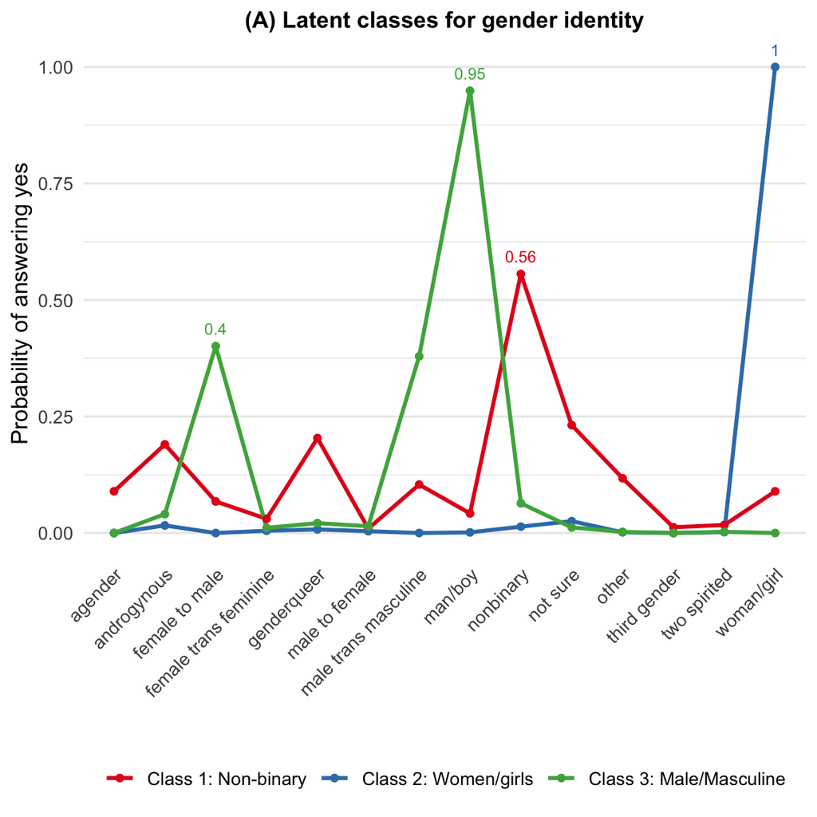

```r
# probabilities of answering yes by class
probs_list <- gender_LCA3$probs

probs_df <- do.call(rbind, lapply(names(probs_list), function(var) {
  prob_df <- as.data.frame(probs_list[[var]])
  prob_df$variable <- var
  prob_df$class <- rownames(prob_df)
  prob_df
})) %>% dplyr::select(-`Pr(1)`)

probs_df_list <- list()


for (var in names(probs_list)) {
  prob_df <- as.data.frame(probs_list[[var]])
  prob_df$variable <- var
  prob_df$class <- rownames(prob_df)
  probs_df_list[[var]] <- prob_df
}


probs_df_combined <- bind_rows(probs_df_list)%>%
  dplyr::select(-`Pr(1)`) %>%
  mutate(variable = dplyr::recode(variable,
    "agender" = "agender",
    "not_sure" = "not sure",
    "other_please_specify" = "other",
    "androgynous" = "androgynous",
    "nonbinary" = "nonbinary",
    "two_spirited" = "two spirited",
    "female_to_male_transgender_ftm" = "female to male",
    "trans_female_trans_feminine" = "female trans feminine",
    "trans_male_trans_masculine" = "male trans masculine",
    "third_gender" = "third gender",
    "genderqueer" = "genderqueer",
    "male_to_female_transgender_mtf" = "male to female",
    "man_boy" = "man/boy",
    "woman_girl" = "woman/girl"
  )) %>%
   mutate(class = dplyr::recode(class,
                                "class 1: " = "Class 1: Non-binary",
                                "class 2: " = "Class 2: Women/girls",
                                "class 3: " = "Class 3: Male/Masculine")
   ) %>%
  group_by(variable) %>%
  mutate(maxprob = max(`Pr(2)`)) %>%
  ungroup() %>%
  mutate(maxprob = ifelse(maxprob==`Pr(2)`,maxprob,NA) %>% round(2),
         maxprob = ifelse(maxprob %in% c(0.01,0.02,0.03,0.12,0.23,0.2,0.19,0.09,0.38),NA,maxprob)
         )

## the condit. prob
gender_prob_plot <- ggplot(probs_df_combined, aes(x = variable, y = `Pr(2)`, color = class, group = class)) +
  geom_line(size = 1) +
  geom_point(size = 1.5)+
  geom_text(aes(label = round(maxprob, 2)), vjust = -1, size = 3, show.legend = FALSE) +
  theme(axis.text.x = element_text(angle = 45, hjust = 1, size = 12)) +
  labs(x = "", y = "Probability of answering yes ") +
   ggtitle("(A) Latent classes for gender identity")+
  scale_color_brewer(palette = "Set1") +
  theme_minimal(base_size = 12) +
  theme(
    plot.title = element_text(hjust = 0.5, size = 12, face = "bold"),
    axis.title.y = element_text(size = 12),
    legend.title = element_blank(),
    legend.position = "bottom",
    axis.text.x = element_text(angle = 45, hjust = 1),
    panel.grid.major.x = element_blank(),
    panel.grid.minor.x = element_blank()
  )

gender_prob_plot
```

```r
ggsave("figures/gender_prob_plot.png", width = 6, height = 6, dpi = 600)
```

### 1.2.2 Coping strategies

#### 1.2.2.1 Step 1: LCA model selection

Build and compare LCA models

```r
cope_dat_LCA <- dem_cope_subset %>%
  recode_variables() %>%
  rename_with(~ str_remove(., "b_covid_cope_1_"), starts_with("b_covid_cope_1_"))


f2 <- cbind(connecting_with_others, contacting_a_healthcare_provider,
        drinking_alcohol, smoking_more_cigarettes_or_vaping_more) ~ 1

set.seed(1017)
cope_LCA2 <- poLCA(f2, data = cope_dat_LCA,
              nclass = 2)
cope_LCA3 <- poLCA(f2, data = cope_dat_LCA,
              nclass = 3)

cope_LCA4 <- poLCA(f2, data = cope_dat_LCA,
              nclass = 4)
cope_LCA5 <- poLCA(f2, data = cope_dat_LCA,
              nclass = 5)

cope_models <- list(cope_LCA2, cope_LCA3, cope_LCA4, cope_LCA5)
cope_model_stats <- data.frame(
  Model = 2:5,
  G2 = sapply(cope_models, function(x) x$Gsq),
  AIC = sapply(cope_models, function(x) x$aic),
  BIC = sapply(cope_models, function(x) x$bic)
)
```

```r
kable(cope_model_stats, caption = "Model Comparison for Different Number of Classes (Coping strategy variable)")
```

Table 1.2: Model Comparison for Different Number of Classes (Coping strategy variable)

| Model | G2 | AIC | BIC |
| --- | --- | --- | --- |
| 2 | 29.066630 | 4548.577 | 4596.402 |
| 3 | 6.162343 | 4535.673 | 4610.067 |
| 4 | 6.058262 | 4545.569 | 4646.533 |
| 5 | 1.878940 | 4551.389 | 4678.923 |

#### 1.2.2.2 Step 2: Classification error: averaged posterior probability(APP)

print averaged posterior probability(APP) for coping strategy, results suggest low classification error(APP>0.7).

```r
posterior_probs <- cope_LCA3$posterior

assigned_class <- apply(posterior_probs, 1, which.max)

mean_posterior_by_class <- numeric(ncol(posterior_probs))

for (k in 1:ncol(posterior_probs)) {
  mean_posterior_by_class[k] <- mean(posterior_probs[assigned_class == k, k])
}

print(mean_posterior_by_class)
```

```
## [1] 0.8685438 0.7917650 0.9089532
```

#### 1.2.2.3 Step 3: Final latent class probabilities

Similarly, get the predicted posterior probability of the latent variable for coping strategy.

```r
## get predicted class (gender identity)
cope_class <- cope_LCA3$predclass
cope_predprob <- cope_LCA3$posterior
colnames(cope_predprob) <- paste0("Class",c(1:3))
cope_predprob %>% datatable(
  rownames = FALSE,
  options = list(
     pageLength = 5,
    columnDefs = list(list(className = 'dt-center',
                      targets = 0:2))))
```

| Class1 | Class2 | Class3 |
| --- | --- | --- |
| 0.04922372435002031 | 0.04506505051663062 | 0.9057112251333491 |
| 0.05778574984480141 | 0.0134183248492888 | 0.9287959253059098 |
| 0.04922372435002031 | 0.04506505051663062 | 0.9057112251333491 |
| 0.1463389554275021 | 0.5422882631037068 | 0.3113727814687912 |
| 0.5935504061081491 | 5.184077975022918e-32 | 0.4064495938918509 |
| 0.1463389554275021 | 0.5422882631037068 | 0.3113727814687912 |
| 0.05541383159393012 | 0.8096107731233886 | 0.1349753952826813 |
| 0.05541383159393012 | 0.8096107731233886 | 0.1349753952826813 |
| 0.05541383159393012 | 0.8096107731233886 | 0.1349753952826813 |
| 0.05541383159393012 | 0.8096107731233886 | 0.1349753952826813 |

[output cut: 1491 more lines]

#### 1.2.2.4 Step 4: Assign label to each latent class (coping strategies)

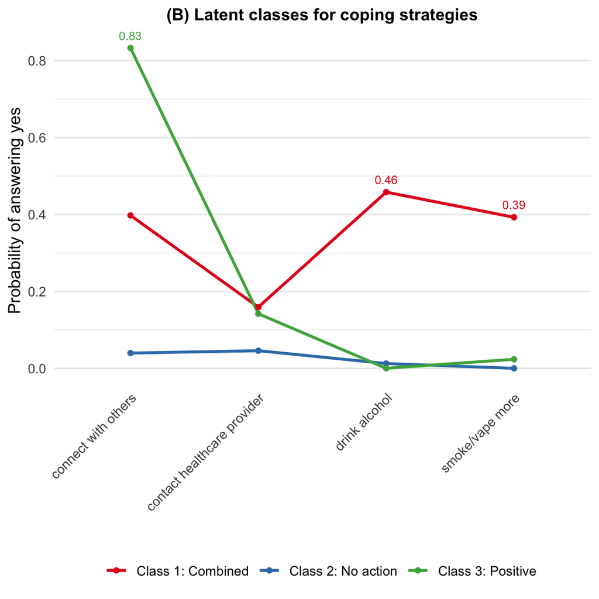

```r
probs_list <- cope_LCA3$probs

probs_df <- do.call(rbind, lapply(names(probs_list), function(var) {
  prob_df <- as.data.frame(probs_list[[var]])
  prob_df$variable <- var
  prob_df$class <- rownames(prob_df)
  prob_df
})) %>% dplyr::select(-`Pr(1)`)

probs_df_list <- list()

for (var in names(probs_list)) {
  prob_df <- as.data.frame(probs_list[[var]])
  prob_df$variable <- var
  prob_df$class <- rownames(prob_df)
  probs_df_list[[var]] <- prob_df
}


probs_df_combined <- bind_rows(probs_df_list)%>%
  dplyr::select(-`Pr(1)`) %>%
   mutate(variable = dplyr::recode(variable,
    "connecting_with_others" = "connect with others",
                      "contacting_a_healthcare_provider" = "contact healthcare provider",
                      "drinking_alcohol" = "drink alcohol",
                      "smoking_more_cigarettes_or_vaping_more" = "smoke/vape more")) %>%
   mutate(class = dplyr::recode(class,
                                "class 3: " = "Class 3: Positive ",
                                "class 2: " = "Class 2: No action",
                                "class 1: " = "Class 1: Combined")
   ) %>%
  group_by(variable) %>%
  mutate(maxprob = max(`Pr(2)`)) %>%
  ungroup() %>%
  mutate(maxprob = ifelse(maxprob==`Pr(2)`,maxprob,NA) %>% round(2),
         maxprob = ifelse(maxprob==0.16,NA,maxprob))

cope_prob_plot <- ggplot(probs_df_combined, aes(x = variable, y = `Pr(2)`, color = class, group = class)) +
  geom_line(size = 1) +
  geom_point(size = 1.5)+
  geom_text(aes(label = round(maxprob, 2)), vjust = -1, size = 3, show.legend = FALSE) +
  theme(axis.text.x = element_text(angle = 45, hjust = 1, size = 12)) +
  labs(x = "", y = "Probability of answering yes ") +
   ggtitle("(B) Latent classes for coping strategies")+
  scale_color_brewer(palette = "Set1") +
  theme_minimal(base_size = 12) +
  theme(
    plot.title = element_text(hjust = 0.5, size = 12, face = "bold"),
    axis.title.y = element_text(size = 12),
    legend.title = element_blank(),
    legend.position = "bottom",
    axis.text.x = element_text(angle = 45, hjust = 1),
    panel.grid.major.x = element_blank(),
    panel.grid.minor.x = element_blank()
  )

cope_prob_plot
```

```r
ggsave("figures/cope_prob_plot.png", width = 6, height = 6, dpi = 600)
```

## 1.3 Missing values

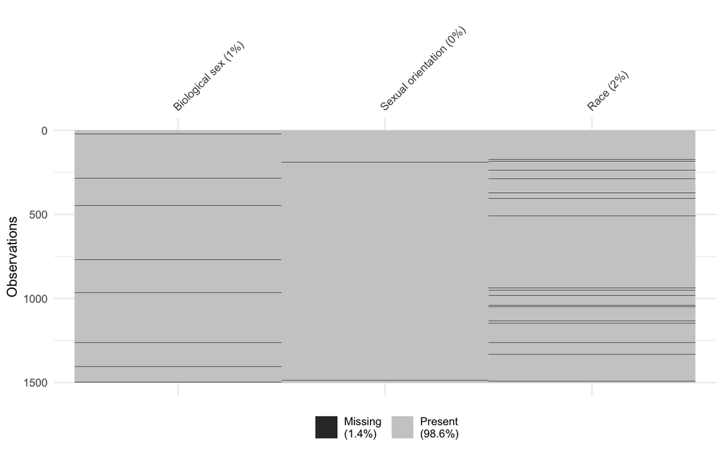

```r
miss_dat <- cope_subset1 %>%

  mutate(across(starts_with("recode_race"), ~ ifelse(. == "Prefer not to answer", NA, .))) %>%

  mutate(b_dem_sex = ifelse(b_dem_sex %in% c("Prefer not to say", "Other"), NA, b_dem_sex)) %>%

  mutate(across(starts_with("recode_orient"), ~ ifelse(. == "I do not want to respond", NA, .)))%>% dplyr::select(b_dem_sex,recode_orient,recode_race)

colnames(miss_dat) <- c("Biological sex","Sexual orientation","Race")

vis_miss(miss_dat)
```

Tabulate the number and percentage of missing. The missing rate is low, so complete case analysis will be used later.

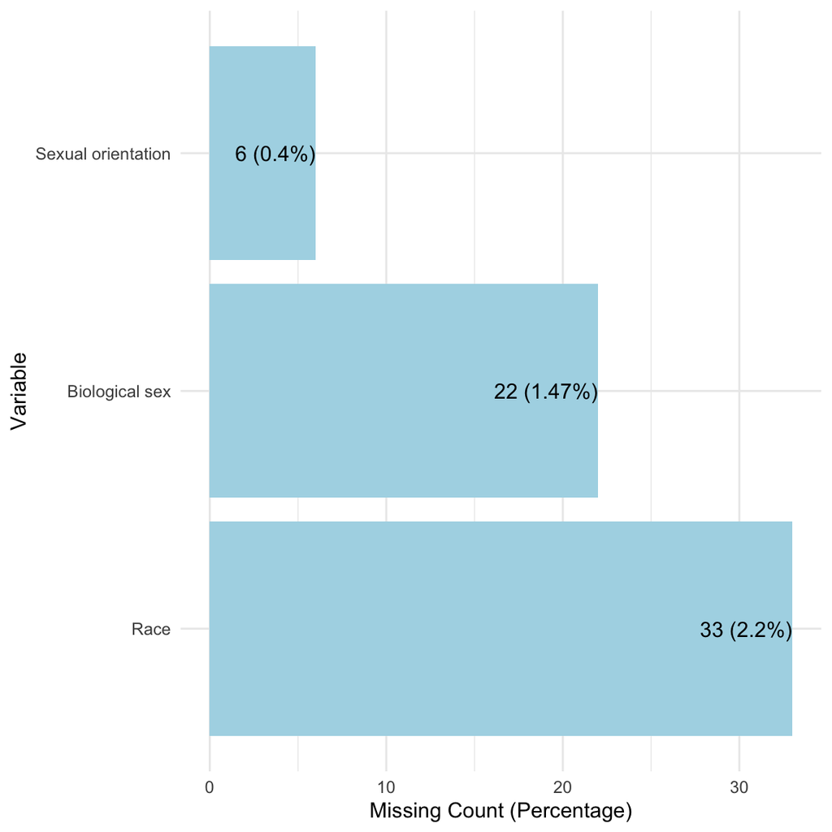

```r
missing_summary <- miss_var_summary(miss_dat)

miss_plot <- ggplot(missing_summary, aes(x = reorder(variable, -n_miss), y = n_miss)) +
  geom_bar(stat = "identity", fill = "lightblue",size=0.1) +
  geom_text(aes(label = paste0(n_miss, " (", round(pct_miss, 2), "%)")),
            hjust = 1,  vjust = 0.5, color = "black") +
  coord_flip() +
  theme_minimal() +
  labs( #title = "Missing Data by Variable",
       x = "Variable",
       y = "Missing Count (Percentage)") +
  theme(axis.text.y = element_text(size = 10),
        axis.title = element_text(size = 12),
        plot.title = element_text(size = 14, face = "bold")) +
 # coord_cartesian(ylim = c(0, 40))+
  theme_minimal()
miss_plot
```

Check if there is any missing pattern among missing variables: No pattern presents!

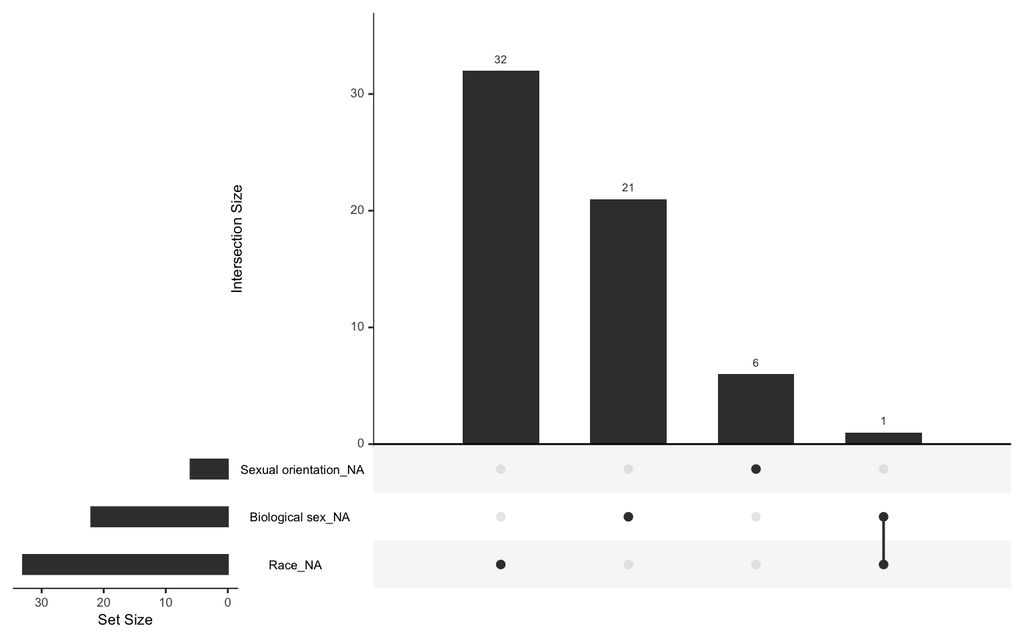

```r
gg_miss_upset(miss_dat)
```

## 1.4 The final working dataset

After some investigation, I decided to do a complete case analysis(CCA), the final working dataset is then generated.

```r
dat_cc <- cope_subset3 %>%
   filter(recode_race!="Prefer not to answer") %>%  ## 1468
  filter(b_dem_sex!="Prefer not to say" & b_dem_sex!="Other") %>% ## 1447
  filter(orientation!="I do not want to respond") ## 1441
```

```r
cope_subset2 <- cope_subset1 %>%

  mutate(across(starts_with("recode_race"), ~ ifelse(. == "Prefer not to answer", NA, .))) %>%

  mutate(b_dem_sex = ifelse(b_dem_sex %in% c("Prefer not to say", "Other"), NA, b_dem_sex)) %>%

  mutate(across(starts_with("recode_orient"), ~ ifelse(. == "I do not want to respond", NA, .)))

## use the latent variable genderid3 as a surragate for a series of gener identity related quesitons
cope_subset2$genderid3 <- genderid_class

## use the latent variable cope3 as a surragate for a series of coping strategies related quesitons
cope_subset2$cope3 <- cope_class

cope_subset3 <- cope_subset2 %>%
  mutate(family_num =challenge_num_dat$challenge_num3,
         family_cat = challenge_cat_dat$challenge_cat) %>%
  dplyr::select(c("b_response_id", "condition", "b_cdi_mean", "f1_cdi_mean", "recode_race",
           #"b_dem_gender_agender", "b_dem_gender_not_sure",
           #"b_dem_gender_other_please_specify", "b_dem_gender_androgynous",
           #"b_dem_gender_nonbinary", "b_dem_gender_two_spirited", "b_dem_gender_female_to_male_transgender_ftm",
           #"b_dem_gender_trans_female_trans_feminine", "b_dem_gender_trans_male_trans_masculine",
           #"b_dem_gender_gender_expansive", "b_dem_gender_third_gender",
           #"b_dem_gender_genderqueer", "b_dem_gender_male_to_female_transgender_mtf",
          # "b_dem_gender_man_boy", "b_dem_gender_transgender", "b_dem_gender_woman_girl",
           "b_screener_age", "b_dem_sex", "recode_orient",
            #"b_covid_family_family_did_not_enough_enough_money_for_food",
           #"b_covid_family_family_did_not_have_a_regular_place_to_sleep_or_stay",
           #"b_covid_family_i_could_not_attend_school_in_person", "b_covid_family_i_could_not_attend_school_at_all",
           #"b_covid_family_other", "b_covid_family_family_did_not_have_enough_money_for_gas_transportation",
           #"b_covid_family_family_did_not_have_enough_money_to_pay_rent",
           #"b_covid_family_the_covid_19_pandemic_has_not_affected_me_or_my_family_in_these_ways_in_the_past_2_weeks",
           #"b_covid_cope_1_connecting_with_others", "b_covid_cope_1_including_talking_with_people_you_trust_about_your_concerns_and_how_you_are_feeling",
           #"b_covid_cope_1_contacting_a_healthcare_provider", "b_covid_cope_1_drinking_alcohol",
           #"b_covid_cope_1_smoking_more_cigarettes_or_vaping_more",
           "recode_language",
           "genderid3","family_num","family_cat",
           # "family3",
          "cope3")) %>%
  mutate(
   # condition = factor(condition),
    recode_race = factor(recode_race),
   # b_screener_age = factor(b_screener_age),
    b_dem_sex = factor(b_dem_sex),
    recode_orient = factor(recode_orient),
    genderid3 = factor(genderid3),
    family_num = factor(family_num),
    family_cat = factor(family_cat),
    cope3 = factor(cope3)
  )

dat_cc <- cope_subset3 %>%
   filter(!is.na(recode_race)) %>%  ## 1468
  filter(!is.na(b_dem_sex)) %>% ## 1447
  filter(!is.na(recode_orient) )## 1441


dat_cc %>%  datatable(
  rownames = FALSE,
  options = list(
    pageLength = 5))
```

| b_response_id | condition | b_cdi_mean | f1_cdi_mean | recode_race | b_screener_age | b_dem_sex | recode_orient | recode_language | genderid3 | family_num | family_cat | cope3 |
| --- | --- | --- | --- | --- | --- | --- | --- | --- | --- | --- | --- | --- |
| R_02uyQw7i0v8yQRX | Placebo Control | 1.41666666666667 | 1 | White | 14 | Female | LGBTQ | English | 1 | 2 | Other | 3 |
| R_06bZX04ieGtQOWJ | Project Personality | 0.916666666666667 | 0.583333333333333 | White | 15 | Female | Other | English | 1 | 2 | Other | 3 |
| R_089oJuXofDsITq9 | Placebo Control | 1.16666666666667 | 0.583333333333333 | White | 16 | Female | LGBTQ | English | 2 | 0 | No impact | 3 |
| R_08lyOxzUAzbJqcV | Placebo Control | 1.33333333333333 | 1.41666666666667 | White | 15 | Female | LGBTQ | English | 2 | 1 | School | 2 |
| R_0dEHbvY9Gs3dYSB | Project Personality | 0.916666666666667 | 0.5 | White | 16 | Female | LGBTQ | English | 2 | 1 | School | 1 |
| R_0e2bSxAqehpqMiR | Project Personality | 1 | 0.666666666666667 | White | 16 | Female | LGBTQ | English | 3 | 1 | School | 2 |
| R_0lDh6r7xrSRAemR | Project ABC | 1 | 0.833333333333333 | Asian Including Asian Desi | 14 | Female | Heterosexual | English | 2 | 1 | School | 2 |
| R_0MWZlutLcSpTEpH | Project Personality | 1.33333333333333 | 1.08333333333333 | Asian Including Asian Desi | 16 | Female | LGBTQ | English | 2 | 1 | School | 2 |
| R_0NSaH6AKKJieJ4R | Placebo Control | 0.916666666666667 | 0.583333333333333 | White | 16 | Female | Heterosexual | English | 2 | 1 | School | 2 |
| R_0Ps1epuV8JY3Wcp | Placebo Control | 1.08333333333333 | 1 | Mixed | 14 | Female | LGBTQ | English | 2 | 2 | Other | 2 |

[output cut: 1431 more lines]

```r
save(dat_cc,file="data/dat_cc.rds")
```

```r
table1_dat <- cope_subset3 %>%

 mutate(genderid3 = dplyr::recode(genderid3,
                                "1" = "Non-binary",
                                "2" = "Women/girls",
                                "3" = "Male/Masculine")
   ) %>%
     mutate(family_num = dplyr::recode(family_num,
                                "0" = "0",
                                "2" = ">=2",
                                "1" = "1")
   )  %>%
  mutate(cope3 = dplyr::recode(cope3,
                                "3" = "Positive",
                                "2" = "No action",
                                "1" = "Combined")
   )  %>%
   filter(!is.na(recode_race)) %>%  ## 1468
  filter(!is.na(b_dem_sex)) %>% ## 1447
  filter(!is.na(recode_orient) )## 1441


colnames(table1_dat) <- c("id", "condition", "Baseline CDI mean score(0-2)", "3-month CDI mean score",
"Race", "Age (yrs)", "Biological sex", "Sexual orientation",
"Language", "Gender identity", "Number of challenges", "Type of challenges", "Type of coping strategies"
)
```

# 2 Descriptive table (table 1)

A Descriptive table is generated using the 1441 subjects with complete data. Summary stats is stratified by treatment condition.

```r
table1_cc <- tbl_summary(table1_dat %>% dplyr::select(-id,-`3-month CDI mean score`),
                      by = condition, statistic = list(all_continuous() ~ "{mean} ({sd})",
                                                                        all_categorical() ~ "{n} ({p}%)"), digits = all_continuous() ~ 2,
                      # label = list(
                      #              b_dem_sex ~ "Biological Sex",
                      #              b_dem_orientation ~ "Sexual Orientation"
                      #              #,
                      #              # b_cdi_sum ~ "Baseline CDI Sum Score (0-24)"
                      #              )
                      ) %>%
  modify_header(label ~ "**Demographics**") %>%
  modify_spanning_header(c("stat_1", "stat_2","stat_3") ~ "**Treatment Received**")
table1_cc
```

| **Demographics** | **Treatment Received** **Placebo Control** N = 488<sup>1</sup> | **Treatment Received** **Project ABC** N = 489<sup>1</sup> | **Treatment Received** **Project Personality** N = 464<sup>1</sup> |
| --- | --- | --- | --- |
| Baseline CDI mean score(0-2) | 1.16 (0.35) | 1.15 (0.34) | 1.17 (0.36) |
| Race |  |  |  |
| Asian Including Asian Desi | 50 (10%) | 58 (12%) | 50 (11%) |
| Black/African-American | 33 (6.8%) | 40 (8.2%) | 36 (7.8%) |
| Hispanic/Latinx | 57 (12%) | 61 (12%) | 53 (11%) |
| Mixed | 74 (15%) | 68 (14%) | 63 (14%) |
| White | 274 (56%) | 262 (54%) | 262 (56%) |
| Age (yrs) |  |  |  |
| 13 | 28 (5.7%) | 32 (6.5%) | 28 (6.0%) |
| 14 | 77 (16%) | 81 (17%) | 63 (14%) |
| 15 | 150 (31%) | 156 (32%) | 162 (35%) |
| 16 | 233 (48%) | 220 (45%) | 211 (45%) |
| Biological sex |  |  |  |
| Female | 434 (89%) | 437 (89%) | 418 (90%) |
| Male | 54 (11%) | 52 (11%) | 46 (9.9%) |
| Sexual orientation |  |  |  |
| Heterosexual | 108 (22%) | 97 (20%) | 106 (23%) |
| LGBTQ | 309 (63%) | 327 (67%) | 291 (63%) |
| Other | 71 (15%) | 65 (13%) | 67 (14%) |
| Language |  |  |  |
| English | 476 (98%) | 476 (97%) | 450 (97%) |
| Other | 12 (2.5%) | 13 (2.7%) | 14 (3.0%) |
| Gender identity |  |  |  |
| Non-binary | 102 (21%) | 98 (20%) | 86 (19%) |
| Women/girls | 313 (64%) | 325 (66%) | 306 (66%) |
| Male/Masculine | 73 (15%) | 66 (13%) | 72 (16%) |
| Number of challenges |  |  |  |
| 0 | 98 (20%) | 99 (20%) | 85 (18%) |
| 1 | 276 (57%) | 297 (61%) | 275 (59%) |
| >=2 | 114 (23%) | 93 (19%) | 104 (22%) |
| Type of challenges |  |  |  |
| No impact | 98 (20%) | 99 (20%) | 85 (18%) |
| Other | 119 (24%) | 97 (20%) | 124 (27%) |
| School | 271 (56%) | 293 (60%) | 255 (55%) |
| Type of coping strategies |  |  |  |
| Combined | 58 (12%) | 61 (12%) | 53 (11%) |
| No action | 228 (47%) | 235 (48%) | 236 (51%) |
| Positive | 202 (41%) | 193 (39%) | 175 (38%) |

<sup>1</sup> Mean (SD); n (%)

```r
## write tex file
table1_df <- as.data.frame(table1_cc)
latex_table1 <- xtable(table1_df)

writeLines(print(latex_table1, type = "latex",include.rownames = FALSE), paste0("table1_df_",Sys.Date(),".tex"))
```

```
## % latex table generated in R 4.3.1 by xtable 1.8-4 package
## % Wed Jul 31 20:43:29 2024
## \begin{table}[ht]
## \centering
## \begin{tabular}{llll}
##   \hline
## **Demographics** & **Placebo Control**
## N = 488 & **Project ABC**
## N = 489 & **Project Personality**
## N = 464 \\
##   \hline
## Baseline CDI mean score(0-2) & 1.16 (0.35) & 1.15 (0.34) & 1.17 (0.36) \\
##   Race &  &  &  \\
##   Asian Including Asian Desi & 50 (10\%) & 58 (12\%) & 50 (11\%) \\
##   Black/African-American & 33 (6.8\%) & 40 (8.2\%) & 36 (7.8\%) \\
##   Hispanic/Latinx & 57 (12\%) & 61 (12\%) & 53 (11\%) \\
##   Mixed & 74 (15\%) & 68 (14\%) & 63 (14\%) \\
##   White & 274 (56\%) & 262 (54\%) & 262 (56\%) \\
##   Age (yrs) &  &  &  \\
##   13 & 28 (5.7\%) & 32 (6.5\%) & 28 (6.0\%) \\
##   14 & 77 (16\%) & 81 (17\%) & 63 (14\%) \\
##   15 & 150 (31\%) & 156 (32\%) & 162 (35\%) \\
##   16 & 233 (48\%) & 220 (45\%) & 211 (45\%) \\
##   Biological sex &  &  &  \\
##   Female & 434 (89\%) & 437 (89\%) & 418 (90\%) \\
##   Male & 54 (11\%) & 52 (11\%) & 46 (9.9\%) \\
##   Sexual orientation &  &  &  \\
##   Heterosexual & 108 (22\%) & 97 (20\%) & 106 (23\%) \\
##   LGBTQ & 309 (63\%) & 327 (67\%) & 291 (63\%) \\
##   Other & 71 (15\%) & 65 (13\%) & 67 (14\%) \\
##   Language &  &  &  \\
##   English & 476 (98\%) & 476 (97\%) & 450 (97\%) \\
##   Other & 12 (2.5\%) & 13 (2.7\%) & 14 (3.0\%) \\
##   Gender identity &  &  &  \\
##   Non-binary & 102 (21\%) & 98 (20\%) & 86 (19\%) \\
##   Women/girls & 313 (64\%) & 325 (66\%) & 306 (66\%) \\
##   Male/Masculine & 73 (15\%) & 66 (13\%) & 72 (16\%) \\
##   Number of challenges &  &  &  \\
##   0 & 98 (20\%) & 99 (20\%) & 85 (18\%) \\
##   1 & 276 (57\%) & 297 (61\%) & 275 (59\%) \\
##   $>$=2 & 114 (23\%) & 93 (19\%) & 104 (22\%) \\
##   Type of challenges &  &  &  \\
##   No impact & 98 (20\%) & 99 (20\%) & 85 (18\%) \\
##   Other & 119 (24\%) & 97 (20\%) & 124 (27\%) \\
##   School & 271 (56\%) & 293 (60\%) & 255 (55\%) \\
##   Type of coping strategies &  &  &  \\
##   Combined & 58 (12\%) & 61 (12\%) & 53 (11\%) \\
##   No action & 228 (47\%) & 235 (48\%) & 236 (51\%) \\
##   Positive & 202 (41\%) & 193 (39\%) & 175 (38\%) \\
##    \hline
## \end{tabular}
## \end{table}
```

```r
age_summary <- table1_dat %>%
  mutate(`Age (yrs)` = as.numeric(`Age (yrs)`)) %>%
  group_by(condition) %>%
  summarise(
    count = n(),
    mean_age = mean(`Age (yrs)`, na.rm = TRUE),
    sd_age = sd(`Age (yrs)`, na.rm = TRUE),
    min_age = min(`Age (yrs)`, na.rm = TRUE),
    max_age = max(`Age (yrs)`, na.rm = TRUE),
    median_age = median(`Age (yrs)`),
    IQR_age = IQR(`Age (yrs)`, na.rm = TRUE)
  )
```

# 3 Baseline CDI Prediction Model

Will use risk-based approach.

The first step is to construct the baseline CDI prediction model. The focus of the “risk” prediction model is on accurately predicting individuals’ “disease” risk. Several considerations need to be taken into account:

**Statistical Model Selection:**

Consideration of models: will use linear model (simple and interpretability)

**Performance Metrics:**

For continuous outcomes, models will be evaluated and selected based on root mean squared error (RMSE), calibration slope, and calibration-at-large.

**Overfitting:**

Employ a leave-one-out cross-validation (LOOCV) framework to address overfitting. LOOCV will be conducted on 80% of the samples (derivation cohort), while the remaining 20% will serve as a test cohort to mimic an external validation. Final model will be constructed on the entire dataset.

```r
## subset data
dat_abc <- dat_cc %>% dplyr::select(-family_num,-recode_language) %>%  ## removed because of corr.
  filter(condition!="Project Personality") %>%## ABC vs control
  mutate(condition = as.character(condition),
         condition = as.factor(condition)
  )
dat_person <- dat_cc %>% dplyr::select(-family_num,-recode_language) %>%
  filter(condition!="Project ABC") %>%  ## Personality vs control
 mutate(condition = as.character(condition),
        condition = as.factor(condition)
        )
```

a glimpse of the variables:

```r
str(dat_abc)
```

```
## tibble [977 × 11] (S3: tbl_df/tbl/data.frame)
##  $ b_response_id : chr [1:977] "R_02uyQw7i0v8yQRX" "R_089oJuXofDsITq9" "R_08lyOxzUAzbJqcV" "R_0lDh6r7xrSRAemR" ...
##  $ condition     : Factor w/ 2 levels "Placebo Control",..: 1 1 1 2 1 1 1 2 2 2 ...
##  $ b_cdi_mean    : num [1:977] 1.417 1.167 1.333 1 0.917 ...
##  $ f1_cdi_mean   : num [1:977] 1 0.583 1.417 0.833 0.583 ...
##  $ recode_race   : Factor w/ 5 levels "Asian Including Asian Desi",..: 5 5 5 1 5 4 5 5 5 5 ...
##  $ b_screener_age: num [1:977] 14 16 15 14 16 14 14 16 16 16 ...
##  $ b_dem_sex     : Factor w/ 2 levels "Female","Male": 1 1 1 1 1 1 1 1 1 1 ...
##  $ recode_orient : Factor w/ 3 levels "Heterosexual",..: 2 2 2 1 1 2 1 1 2 2 ...
##  $ genderid3     : Factor w/ 3 levels "1","2","3": 1 2 2 2 2 2 2 2 2 2 ...
##  $ family_cat    : Factor w/ 3 levels "No impact","Other",..: 2 1 3 3 3 2 3 2 3 2 ...
##  $ cope3         : Factor w/ 3 levels "1","2","3": 3 3 2 2 2 2 2 2 2 2 ...
```

## 3.1 Build prediction model

Build prediction models using `caret`

```r
basemodel_dat <- dat_abc %>% dplyr::select(-condition,-b_cdi_mean,-b_response_id,-b_screener_age,)
set.seed(1017)

trainIndex <- createDataPartition(basemodel_dat$f1_cdi_mean, p = .8, list = FALSE, times = 1)
trainData <- basemodel_dat[trainIndex, ]
testData <- basemodel_dat[-trainIndex, ]



train_control <- trainControl(method = "LOOCV")

#train_control <- trainControl(method = "cv", number = 3)

# rf_model <- train(f1_cdi_mean ~ .,
#                   data = trainData,
#                   method = "rf",
#                   trControl = train_control)
tune_grid <- expand.grid(alpha = 0,
                         lambda = 10^seq(-3, 1, length = 10))

abc_model <- train(f1_cdi_mean ~ .,
                  data = trainData,
                  method = "glmnet",
                  trControl = train_control,
                  tuneGrid = tune_grid,
                  metric = "RMSE")

valid_pred <- predict(abc_model, newdata = trainData)

test_pred <- predict(abc_model, newdata = testData)

## mse
rmse_f <- function(actual, pred) {
  sqrt(mean((actual - pred) ^ 2))
}


## perf metrics
### rmse
valid_rmse <- rmse_f(trainData$f1_cdi_mean, valid_pred)
test_rmse <- rmse_f(testData$f1_cdi_mean, test_pred)

### calibration slope & at large
valid_cali_m <- lm(trainData$f1_cdi_mean~ valid_pred)
valid_cali_slope <- coef(valid_cali_m)[2]
valid_cali_at_large <- coef(valid_cali_m)[1]

test_cali_m <- lm(testData$f1_cdi_mean~ test_pred)
test_cali_slope <- coef(test_cali_m)[2]
test_cali_at_large <- coef(test_cali_m)[1]

perf_abc <- data.frame(
  Metric = c("RMSE", "Calibration Slope", "Calibration at Large"),
  Validation = c(valid_rmse, valid_cali_slope, valid_cali_at_large),
  Test = c(test_rmse, test_cali_slope, test_cali_at_large)
)
```

```r
basemodel_dat <- dat_person%>% dplyr::select(-condition,-b_cdi_mean,-b_response_id,-b_screener_age,)
set.seed(1017)

trainIndex <- createDataPartition(basemodel_dat$f1_cdi_mean, p = .8, list = FALSE, times = 1)
trainData <- basemodel_dat[trainIndex, ]
testData <- basemodel_dat[-trainIndex, ]



train_control <- trainControl(method = "LOOCV")

#train_control <- trainControl(method = "cv", number = 3)

# rf_model <- train(f1_cdi_mean ~ .,
#                   data = trainData,
#                   method = "rf",
#                   trControl = train_control)
tune_grid <- expand.grid(alpha = 0,
                         lambda = 10^seq(-3, 1, length = 10))
person_model <- train(f1_cdi_mean ~ .,
                  data = trainData,
                  method = "glmnet",
                  trControl = train_control,
                  tuneGrid = tune_grid,
                  metric = "RMSE")

valid_pred <- predict(person_model, newdata = trainData)

test_pred <- predict(person_model, newdata = testData)

## mse
rmse_f <- function(actual, pred) {
  sqrt(mean((actual - pred) ^ 2))
}


## perf metrics
### rmse
valid_rmse <- rmse_f(trainData$f1_cdi_mean, valid_pred)
test_rmse <- rmse_f(testData$f1_cdi_mean, test_pred)

### calibration slope & at large
valid_cali_m <- lm(trainData$f1_cdi_mean~ valid_pred)
valid_cali_slope <- coef(valid_cali_m)[2]
valid_cali_at_large <- coef(valid_cali_m)[1]

test_cali_m <- lm(testData$f1_cdi_mean~ test_pred)
test_cali_slope <- coef(test_cali_m)[2]
test_cali_at_large <- coef(test_cali_m)[1]

perf_person <- data.frame(
  Metric = c("RMSE", "Calibration Slope", "Calibration at Large"),
  Validation = c(valid_rmse, valid_cali_slope, valid_cali_at_large),
  Test = c(test_rmse, test_cali_slope, test_cali_at_large)
)
```

Summary of baseline model output of project ABC model:

```r
abc_model %>% summary()
```

```
##             Length Class      Mode
## a0           100   -none-     numeric
## beta        1300   dgCMatrix  S4
## df           100   -none-     numeric
## dim            2   -none-     numeric
## lambda       100   -none-     numeric
## dev.ratio    100   -none-     numeric
## nulldev        1   -none-     numeric
## npasses        1   -none-     numeric
## jerr           1   -none-     numeric
## offset         1   -none-     logical
## call           5   -none-     call
## nobs           1   -none-     numeric
## lambdaOpt      1   -none-     numeric
## xNames        13   -none-     character
## problemType    1   -none-     character
## tuneValue      2   data.frame list
## obsLevels      1   -none-     logical
## param          0   -none-     list
```

Summary of baseline model output of project personality model:

```r
person_model %>% summary()
```

```
##             Length Class      Mode
## a0           100   -none-     numeric
## beta        1300   dgCMatrix  S4
## df           100   -none-     numeric
## dim            2   -none-     numeric
## lambda       100   -none-     numeric
## dev.ratio    100   -none-     numeric
## nulldev        1   -none-     numeric
## npasses        1   -none-     numeric
## jerr           1   -none-     numeric
## offset         1   -none-     logical
## call           5   -none-     call
## nobs           1   -none-     numeric
## lambdaOpt      1   -none-     numeric
## xNames        13   -none-     character
## problemType    1   -none-     character
## tuneValue      2   data.frame list
## obsLevels      1   -none-     logical
## param          0   -none-     list
```

## 3.2 Evaluate model performance

Summaries the model performance in the following table:

```r
rownames(perf_abc) <- c()
rownames(perf_person) <- c()

kable(perf_abc, caption = "Model performance of baseline risk model (project ABC)")
```

Table 3.1: Model performance of baseline risk model (project ABC)

| Metric | Validation | Test |
| --- | --- | --- |
| RMSE | 0.3992314 | 0.3959155 |
| Calibration Slope | 1.1575945 | 0.9232901 |
| Calibration at Large | -0.1543406 | 0.0670571 |

```r
kable(perf_person, caption = "Model performance of baseline risk model (project personality)")
```

Table 3.1: Model performance of baseline risk model (project personality)

| Metric | Validation | Test |
| --- | --- | --- |
| RMSE | 0.4060065 | 0.4228190 |
| Calibration Slope | 1.1999212 | 0.0562373 |
| Calibration at Large | -0.1975490 | 0.9354951 |

## 3.3 Final baseline prediciton model

The final model is constructed on the entire dataset

```r
basemodel_dat_abc <- dat_abc %>% dplyr::select(-condition,-b_cdi_mean,-b_response_id,-b_screener_age,)

abc_base_m <- lm(basemodel_dat_abc$f1_cdi_mean~.,data = basemodel_dat_abc)

sjPlot::tab_model(abc_base_m)
```

|  | Dependent variable |  |  |
| --- | --- | --- | --- |
| Predictors | Estimates | CI | p |
| (Intercept) | 1.06 | 0.92 – 1.21 | **<0.001** |
| recode race [Black/African-American] | -0.04 | -0.16 – 0.08 | 0.527 |
| recode race [Hispanic/Latinx] | -0.08 | -0.19 – 0.02 | 0.129 |
| recode race [Mixed] | -0.03 | -0.13 – 0.08 | 0.617 |
| recode race [White] | 0.03 | -0.05 – 0.12 | 0.462 |
| b dem sex [Male] | -0.15 | -0.25 – -0.04 | **0.007** |
| recode orient [LGBTQ] | 0.09 | 0.02 – 0.16 | **0.010** |
| recode orient [Other] | 0.12 | 0.03 – 0.22 | **0.008** |
| genderid3 [2] | -0.13 | -0.20 – -0.06 | **<0.001** |
| genderid3 [3] | -0.02 | -0.12 – 0.08 | 0.687 |
| family cat [Other] | 0.07 | -0.01 – 0.15 | 0.070 |
| family cat [School] | 0.03 | -0.03 – 0.10 | 0.313 |
| cope3 [2] | -0.06 | -0.14 – 0.02 | 0.137 |
| cope3 [3] | -0.16 | -0.24 – -0.08 | **<0.001** |
| Observations | 977 |  |  |
| R<sup>2</sup> / R<sup>2</sup> adjusted | 0.079 / 0.067 |  |  |

```r
basemodel_dat_person <- dat_person %>% dplyr::select(-condition,-b_cdi_mean,-b_response_id,-b_screener_age,)

person_base_m <- lm(basemodel_dat_person$f1_cdi_mean~.,data = basemodel_dat_person)

sjPlot::tab_model(person_base_m)
```

|  | Dependent variable |  |  |
| --- | --- | --- | --- |
| Predictors | Estimates | CI | p |
| (Intercept) | 1.16 | 1.00 – 1.31 | **<0.001** |
| recode race [Black/African-American] | -0.06 | -0.18 – 0.07 | 0.387 |
| recode race [Hispanic/Latinx] | -0.05 | -0.16 – 0.06 | 0.382 |
| recode race [Mixed] | -0.03 | -0.14 – 0.08 | 0.552 |
| recode race [White] | -0.00 | -0.09 – 0.09 | 0.937 |
| b dem sex [Male] | -0.11 | -0.22 – 0.01 | 0.066 |
| recode orient [LGBTQ] | 0.07 | 0.00 – 0.14 | **0.046** |
| recode orient [Other] | 0.06 | -0.03 – 0.16 | 0.182 |
| genderid3 [2] | -0.15 | -0.22 – -0.08 | **<0.001** |
| genderid3 [3] | -0.10 | -0.21 – -0.00 | **0.049** |
| family cat [Other] | 0.02 | -0.06 – 0.10 | 0.625 |
| family cat [School] | -0.02 | -0.09 – 0.05 | 0.664 |
| cope3 [2] | -0.06 | -0.15 – 0.03 | 0.194 |
| cope3 [3] | -0.13 | -0.22 – -0.04 | **0.005** |
| Observations | 952 |  |  |
| R<sup>2</sup> / R<sup>2</sup> adjusted | 0.052 / 0.039 |  |  |

The distribution of predicted CDI mean score can be plotted to check the baseline ‘risk’/ heterogeneity of individuals.

### 3.3.1 Project ABC baseline model

A summary of the baseline prediction model, for project ABC:

```r
summary(abc_base_m)
```

```
##
## Call:
## lm(formula = basemodel_dat_abc$f1_cdi_mean ~ ., data = basemodel_dat_abc)
##
## Residuals:
##     Min      1Q  Median      3Q     Max
## -1.1440 -0.2760 -0.0133  0.2692  1.1925
##
## Coefficients:
##                                   Estimate Std. Error t value Pr(>|t|)
## (Intercept)                        1.06451    0.07474  14.244  < 2e-16 ***
## recode_raceBlack/African-American -0.03859    0.06095  -0.633 0.526784
## recode_raceHispanic/Latinx        -0.08206    0.05398  -1.520 0.128810
## recode_raceMixed                  -0.02645    0.05288  -0.500 0.617046
## recode_raceWhite                   0.03192    0.04335   0.736 0.461680
## b_dem_sexMale                     -0.14724    0.05401  -2.726 0.006529 **
## recode_orientLGBTQ                 0.08879    0.03424   2.593 0.009645 **
## recode_orientOther                 0.12388    0.04682   2.646 0.008283 **
## genderid32                        -0.13056    0.03508  -3.722 0.000209 ***
## genderid33                        -0.02048    0.05082  -0.403 0.686981
## family_catOther                    0.07276    0.04017   1.811 0.070412 .
## family_catSchool                   0.03368    0.03338   1.009 0.313269
## cope32                            -0.06230    0.04189  -1.487 0.137283
## cope33                            -0.15836    0.04245  -3.730 0.000203 ***
## ---
## Signif. codes:  0 '***' 0.001 '**' 0.01 '*' 0.05 '.' 0.1 ' ' 1
##
## Residual standard error: 0.4005 on 963 degrees of freedom
## Multiple R-squared:  0.0794, Adjusted R-squared:  0.06697
## F-statistic: 6.389 on 13 and 963 DF,  p-value: 1.048e-11
```

### 3.3.2 Project personality baseline model

for project personality:

```r
summary(person_base_m)
```

```
##
## Call:
## lm(formula = basemodel_dat_person$f1_cdi_mean ~ ., data = basemodel_dat_person)
##
## Residuals:
##      Min       1Q   Median       3Q      Max
## -0.98944 -0.27911 -0.01491  0.28285  1.12213
##
## Coefficients:
##                                    Estimate Std. Error t value Pr(>|t|)
## (Intercept)                        1.158568   0.078765  14.709  < 2e-16 ***
## recode_raceBlack/African-American -0.056168   0.064898  -0.865  0.38699
## recode_raceHispanic/Latinx        -0.050336   0.057557  -0.875  0.38205
## recode_raceMixed                  -0.033009   0.055461  -0.595  0.55187
## recode_raceWhite                  -0.003607   0.045772  -0.079  0.93720
## b_dem_sexMale                     -0.105266   0.057114  -1.843  0.06563 .
## recode_orientLGBTQ                 0.069129   0.034617   1.997  0.04612 *
## recode_orientOther                 0.064295   0.048159   1.335  0.18218
## genderid32                        -0.148311   0.036850  -4.025 6.16e-05 ***
## genderid33                        -0.104348   0.052909  -1.972  0.04888 *
## family_catOther                    0.020051   0.041007   0.489  0.62498
## family_catSchool                  -0.015422   0.035546  -0.434  0.66449
## cope32                            -0.057872   0.044475  -1.301  0.19351
## cope33                            -0.128785   0.045462  -2.833  0.00471 **
## ---
## Signif. codes:  0 '***' 0.001 '**' 0.01 '*' 0.05 '.' 0.1 ' ' 1
##
## Residual standard error: 0.4121 on 938 degrees of freedom
## Multiple R-squared:  0.05182,    Adjusted R-squared:  0.03868
## F-statistic: 3.944 on 13 and 938 DF,  p-value: 2.749e-06
```

# 4 Investigate HTE

## 4.1 Main effect only model

first, replicate the model in the original paper for comparison. the main effect model which adjusted for baseline CDI score is specified as:
$$E(Y|\bf{X}) = \text{baseline CDI}+ \text{condition}$$

```r
abc_main_dat <- dat_abc %>%  dplyr::select(f1_cdi_mean,condition,b_cdi_mean)

abc_main_m <- lm(f1_cdi_mean~ b_cdi_mean + condition,data=abc_main_dat)

person_main_dat <- dat_person %>%  dplyr::select(f1_cdi_mean,condition,b_cdi_mean)

person_main_m <- lm(f1_cdi_mean~ b_cdi_mean + condition,data=person_main_dat)
```

print the model, compare with the published paper (results are similar): for project ABC vs control:

```r
abc_main_m %>% summary()
```

```
##
## Call:
## lm(formula = f1_cdi_mean ~ b_cdi_mean + condition, data = abc_main_dat)
##
## Residuals:
##      Min       1Q   Median       3Q      Max
## -1.18567 -0.21921  0.01075  0.22509  1.04660
##
## Coefficients:
##                      Estimate Std. Error t value Pr(>|t|)
## (Intercept)           0.27471    0.04097   6.705 3.42e-11 ***
## b_cdi_mean            0.64303    0.03263  19.706  < 2e-16 ***
## conditionProject ABC -0.07953    0.02234  -3.560 0.000389 ***
## ---
## Signif. codes:  0 '***' 0.001 '**' 0.01 '*' 0.05 '.' 0.1 ' ' 1
##
## Residual standard error: 0.3492 on 974 degrees of freedom
## Multiple R-squared:  0.2922, Adjusted R-squared:  0.2907
## F-statistic:   201 on 2 and 974 DF,  p-value: < 2.2e-16
```

for project personality vs control:

```r
person_main_m %>% summary()
```

```
##
## Call:
## lm(formula = f1_cdi_mean ~ b_cdi_mean + condition, data = person_main_dat)
##
## Residuals:
##      Min       1Q   Median       3Q      Max
## -1.17752 -0.22054  0.01222  0.23434  1.03109
##
## Coefficients:
##                              Estimate Std. Error t value Pr(>|t|)
## (Intercept)                   0.31125    0.04188   7.432 2.38e-13 ***
## b_cdi_mean                    0.61148    0.03329  18.366  < 2e-16 ***
## conditionProject Personality -0.06895    0.02337  -2.950  0.00325 **
## ---
## Signif. codes:  0 '***' 0.001 '**' 0.01 '*' 0.05 '.' 0.1 ' ' 1
##
## Residual standard error: 0.3604 on 949 degrees of freedom
## Multiple R-squared:  0.2664, Adjusted R-squared:  0.2649
## F-statistic: 172.3 on 2 and 949 DF,  p-value: < 2.2e-16
```

## 4.2 HTE model

The HTE is defined as:
$$E(Y|\bf{X}) = \text{baseline CDI}+ \text{condition} + \text{lp}+\text{condition}\times \text{lp}$$
where lp is the linear predictor of the baseline model.

```r
lp_abc <- predict(abc_base_m, dat_abc)
lp_person <- predict(person_base_m, dat_person)

abc_hte_m <- lm(f1_cdi_mean~ b_cdi_mean + condition*lp_abc,data=dat_abc)
person_hte_m <- lm(f1_cdi_mean~ b_cdi_mean + condition*lp_person,data=dat_person)
```

### 4.2.1 HTE Project ABC

The hte model for Project ABC vs control:

```r
summary(abc_hte_m)
```

```
##
## Call:
## lm(formula = f1_cdi_mean ~ b_cdi_mean + condition * lp_abc, data = dat_abc)
##
## Residuals:
##      Min       1Q   Median       3Q      Max
## -1.16587 -0.21245  0.01587  0.22319  1.04761
##
## Coefficients:
##                             Estimate Std. Error t value Pr(>|t|)
## (Intercept)                  0.20672    0.13296   1.555   0.1203
## b_cdi_mean                   0.60042    0.03517  17.070   <2e-16 ***
## conditionProject ABC        -0.46326    0.18742  -2.472   0.0136 *
## lp_abc                       0.11985    0.14022   0.855   0.3929
## conditionProject ABC:lp_abc  0.39263    0.19023   2.064   0.0393 *
## ---
## Signif. codes:  0 '***' 0.001 '**' 0.01 '*' 0.05 '.' 0.1 ' ' 1
##
## Residual standard error: 0.3471 on 972 degrees of freedom
## Multiple R-squared:  0.302,  Adjusted R-squared:  0.2991
## F-statistic: 105.1 on 4 and 972 DF,  p-value: < 2.2e-16
```

### 4.2.2 HTE Project personality

The hte model for Project personality vs control:

```r
summary(person_hte_m)
```

```
##
## Call:
## lm(formula = f1_cdi_mean ~ b_cdi_mean + condition * lp_person,
##     data = dat_person)
##
## Residuals:
##     Min      1Q  Median      3Q     Max
## -1.1604 -0.2189  0.0176  0.2321  1.0427
##
## Coefficients:
##                                        Estimate Std. Error t value Pr(>|t|)
## (Intercept)                             0.18881    0.16684   1.132    0.258
## b_cdi_mean                              0.58760    0.03544  16.580   <2e-16 ***
## conditionProject Personality           -0.28385    0.24270  -1.170    0.242
## lp_person                               0.15184    0.17399   0.873    0.383
## conditionProject Personality:lp_person  0.21744    0.24431   0.890    0.374
## ---
## Signif. codes:  0 '***' 0.001 '**' 0.01 '*' 0.05 '.' 0.1 ' ' 1
##
## Residual standard error: 0.3599 on 947 degrees of freedom
## Multiple R-squared:   0.27,  Adjusted R-squared:  0.2669
## F-statistic: 87.56 on 4 and 947 DF,  p-value: < 2.2e-16
```

# 5 Evaluate HTE

The HTE is evaluated using calibration plot.

## 5.1 Point estiamtes

```r
## compute average treatment effect
#ate_dat <- dat_abc

# ate_dat$condition = 'Placebo Control'
#
# abc_ate_ctrl <- predict(abc_main_m,ate_dat)
#
# ate_dat$condition  = 'Project ABC'
#
# abc_ate_trt <- predict(abc_main_m,ate_dat)
#
# abc_ate_trt-abc_ate_ctrl

abc_ate <- coef(abc_main_m)[3]
person_ate <- coef(person_main_m)[3]

## cATE/HTE
## project ABC vs control
hte_dat <- dat_abc

hte_dat$condition = 'Placebo Control'
abc_hte_ctrl <- predict(abc_hte_m,hte_dat)

hte_dat$condition  = 'Project ABC'
abc_hte_trt <- predict(abc_hte_m,hte_dat)

abc_hte <- abc_hte_trt-abc_hte_ctrl

## hte personality vs control
hte_dat <- dat_person

hte_dat$condition = 'Placebo Control'
person_hte_ctrl <- predict(person_hte_m,hte_dat)

hte_dat$condition  = 'Project Personality'
person_hte_trt <- predict(person_hte_m,hte_dat)
person_hte <- person_hte_trt-person_hte_ctrl


point_df <- data.frame(Comparsion= c("Project ABC vs Control","Project personality vs Control" ),
                       ATE = c(abc_ate,person_ate),
                       SE = c(summary(abc_main_m)$coefficients[, "Std. Error"][3],
                              summary(person_main_m)$coefficients[, "Std. Error"][3])
                       )

kable(point_df, caption = "summary of avearged treatment effect")
```

|  | Comparsion | ATE | SE |
| --- | --- | --- | --- |
| conditionProject ABC | Project ABC vs Control | -0.0795347 | 0.0223413 |
| conditionProject Personality | Project personality vs Control | -0.0689513 | 0.0233696 |

```r
## calibration plot
abc_cal_dat <- data.frame(abc_ate,
                      abc_hte,
                      lp_abc)

abc_cal_dat$quantile_grp <- cut(abc_cal_dat$lp_abc,
                           breaks = quantile(abc_cal_dat$lp_abc, probs = seq(0, 1, by = 0.2)),
                           include.lowest = TRUE,
                           labels = FALSE)

## compute the averaged hte effect in each quantile risk grp
abc_avg_hte <- abc_cal_dat %>%
  group_by(quantile_grp) %>%
  summarise(abc_avg_hte = mean(abc_hte, na.rm = TRUE))
```

```r
## replciate for project personality vs control

## calibration plot
person_cal_dat <- data.frame(person_ate,
                          person_hte,
                          lp_person)

person_cal_dat$quantile_grp <- cut(person_cal_dat$lp_person,
                               breaks = quantile(person_cal_dat$lp_person, probs = seq(0, 1, by = 0.2)),
                               include.lowest = TRUE,
                               labels = FALSE)

## compute the averaged hte effect in each quantile risk grp
person_avg_hte <- person_cal_dat %>%
  group_by(quantile_grp) %>%
  summarise(person_avg_hte = mean(person_hte, na.rm = TRUE))

## compute bootstrapped CI
set.seed(1017)
person_boot_res <- NULL
for (i in 1:1000){
  boot.idx <- sample(1:dim(person_cal_dat)[1], size = dim(person_cal_dat)[1], replace = T)
  boot.data <- person_cal_dat[boot.idx,]
  boot.data$quantile_grp <- cut(boot.data$lp_person,
                                  breaks = quantile(boot.data$lp_person, probs = seq(0, 1, by = 0.2)),
                                  include.lowest = TRUE,
                                  labels = FALSE)

  person_avg_hte <- boot.data %>%
    group_by(quantile_grp) %>%
    summarise(person_avg_hte = mean(person_hte, na.rm = TRUE))

  person_boot_res <- rbind(person_boot_res,person_avg_hte)
}

person_boot_cali_ci <- person_boot_res %>%
  group_by(quantile_grp) %>%
  summarise(
    lower_quantile = round(quantile(person_avg_hte, probs = 0.025), 4),
    upper_quantile = round(quantile(person_avg_hte, probs = 0.975), 4)
  )


person_cali_result <- left_join(person_avg_hte,person_boot_cali_ci)
```

## 5.2 Bootstrapped CI

compute bootstrapped CI for cATE:

```r
## define bootstrap function
boot_f <- function(mydat=NULL,seed=1017){
  set.seed(seed)
  abc_boot_res <- NULL
  for (i in 1:1000){
    boot.idx <- sample(1:dim(mydat)[1], size = dim(mydat)[1], replace = T)
    boot.data <- mydat[boot.idx,]

    abc_main_dat <- boot.data %>%  dplyr::select(f1_cdi_mean,condition,b_cdi_mean)

    abc_main_m <- lm(f1_cdi_mean~ b_cdi_mean + condition,data=abc_main_dat)

    lp_abc <- predict(abc_main_m,boot.data)

    abc_ate <- coef(abc_main_m)[3]

    abc_hte_m <- lm(f1_cdi_mean~ b_cdi_mean + condition*lp_abc,data=boot.data)

    ## cATE/HTE
    ## project ABC vs control
    hte_dat <- boot.data

    trt_levels <- unique(boot.data$condition) %>% as.character()

    trt <- trt_levels[!(trt_levels %in% 'Placebo Control')]

    hte_dat$condition = 'Placebo Control'
    abc_hte_ctrl <- predict(abc_hte_m,hte_dat)

    hte_dat$condition  = trt
    abc_hte_trt <- predict(abc_hte_m,hte_dat)

    abc_hte <- abc_hte_trt-abc_hte_ctrl



    ## calibration plot
    abc_cal_dat <- data.frame(abc_ate,
                              abc_hte,
                              lp_abc)

    abc_cal_dat$quantile_grp <- cut(abc_cal_dat$lp_abc,
                                    breaks = quantile(abc_cal_dat$lp_abc, probs = seq(0, 1, by = 0.2)),
                                    include.lowest = TRUE,
                                    labels = FALSE)

    ## compute the averaged hte effect in each quantile risk grp
    avg_hte <- abc_cal_dat %>%
      group_by(quantile_grp) %>%
      summarise(avg_hte = mean(abc_hte, na.rm = TRUE))

    abc_boot_res <- rbind(abc_boot_res,avg_hte)
  }
  return(abc_boot_res)
}
```

```r
## compute bootstrapped CI
abc_boot_res <- boot_f(mydat = dat_abc)
abc_boot_cali_ci <- abc_boot_res %>%
  group_by(quantile_grp) %>%
  summarise(
    lower_quantile = round(quantile(avg_hte, probs = 0.025), 4),
    upper_quantile = round(quantile(avg_hte, probs = 0.975), 4)
  )
abc_cali_result <- left_join(abc_avg_hte,abc_boot_cali_ci)
```

for Project personality:

```r
## for personality

person_boot_res <- boot_f(mydat = dat_person)

person_boot_cali_ci <- person_boot_res %>%
  group_by(quantile_grp) %>%
  summarise(
    lower_quantile = round(quantile(avg_hte, probs = 0.025), 4),
    upper_quantile = round(quantile(avg_hte, probs = 0.975), 4)
  )


person_cali_result <- left_join(person_avg_hte,person_boot_cali_ci)

## identify the bounds for cali plots

max_cali_y <- max(abc_cali_result$upper_quantile,person_cali_result$upper_quantile)

min_cali_y <- min(abc_cali_result$lower_quantile,person_cali_result$lower_quantile)

## check if the ylims are correct
### I used -0.2 and 0.5 range for the y axis in the calibration plots

logic1 <- min_cali_y <=  0.05 & min_cali_y >=-0.2

logic2 <- max_cali_y <=  0.05 & max_cali_y >=-0.2

if(!logic1 & ! logic2){
  print(paste0("please make sure the range of y axis in the following calibration plot is [", min_cali_y, ",",max_cali_y,']'))
}else{logic_3 = logic1+logic2}
```

## 5.3 Calibration plots

The linear predictor entered model as a continuous variable. For presentation purpose, the linear predictor is discretized into five “risk” groups using quantiles (0.2 incremental). The averaged HTEs/cATEs by “risk” group are calculated and compared with the ATE.

```r
abc_cali_plot <- ggplot(abc_cali_result, aes(x = as.factor(quantile_grp), y = abc_avg_hte)) +
  geom_point(size = 2.5) +
  # geom_line(aes(group = 1), color = "blue") +
  geom_errorbar(aes(ymin = lower_quantile, ymax = upper_quantile), width = 0.05, color = "black") +
  labs(x = "",
       y = "Mean heter_mean_diff"
       # title = ""
  ) +
  geom_hline(yintercept = abc_ate, linetype = "dashed", color = "grey")+
  theme_minimal()+
  scale_y_continuous(
    limits = c(-0.2, 0.05),
    breaks = seq(-0.2, 0.05, by = 0.05)
  )+
 # ylim(c(min_cali_y,max_cali_y))+
  ylab("Mean difference")+
  # ylab(expression(atop("Risk Difference, %", atop("Harm" %<-% phantom("     ") %->% "Benefit")))) +  # Custom y-axis label
  theme(axis.title.y = element_text(angle = 90, vjust = 0.5, size = 14))
```

For Project ABC vs control:

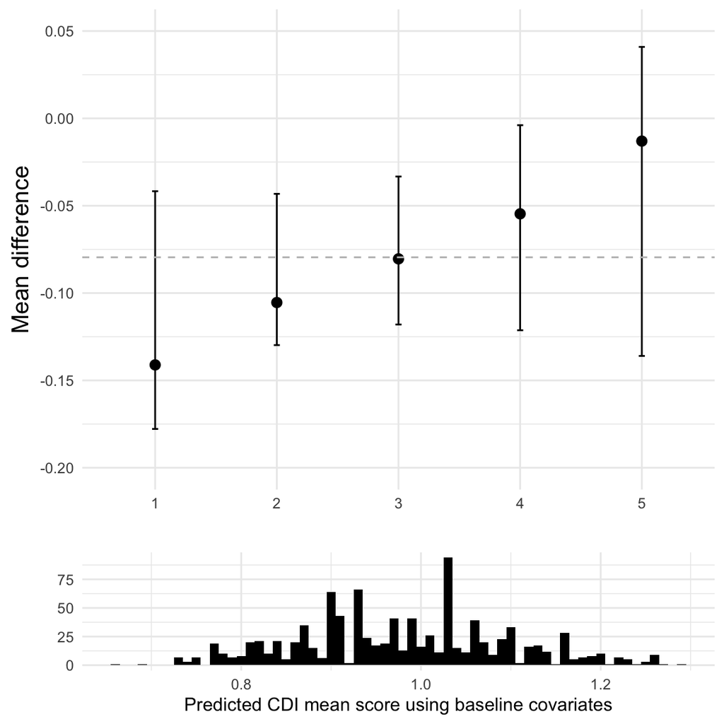

```r
abc_lp_plot <- ggplot(abc_cal_dat, aes(x = lp_abc)) +
  geom_histogram(binwidth = 0.01, fill = "black") +
  labs(x = "Predicted CDI mean score using baseline covariates", y = NULL) +
  theme_minimal()

abc_combo_plot <- cowplot::plot_grid(
  abc_cali_plot,
  abc_lp_plot,
  ncol = 1,
  align = "v",
  rel_heights = c(3, 1)
)

# Display the combined plot
abc_combo_plot
```

For Project personality vs control:

```r
person_cali_plot <- ggplot(person_cali_result, aes(x = as.factor(quantile_grp), y = person_avg_hte)) +
  geom_point(size = 2.5) +
  # geom_line(aes(group = 1), color = "blue") +
  geom_errorbar(aes(ymin = lower_quantile, ymax = upper_quantile), width = 0.05, color = "black") +
  labs(x = "",
       y = "Mean heter_mean_diff"
       # title = ""
       ) +
  geom_hline(yintercept = person_ate, linetype = "dashed", color = "grey")+
  theme_minimal()+
  scale_y_continuous(
    limits = c(-0.2, 0.05),
    breaks = seq(-0.2, 0.05, by = 0.05)
  )+
  ylab("Mean difference")+
 # ylab(expression(atop("Risk Difference, %", atop("Harm" %<-% phantom("     ") %->% "Benefit")))) +  # Custom y-axis label
  theme(axis.title.y = element_text(angle = 90, vjust = 0.5, size = 14))
```

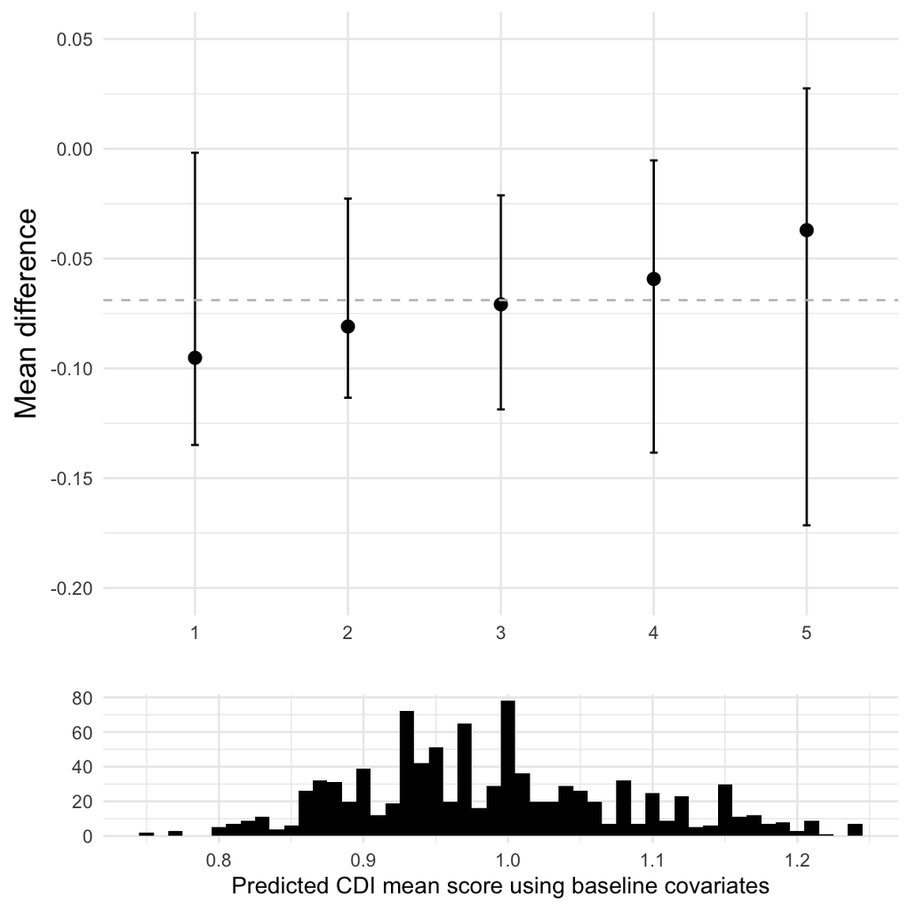

```r
person_lp_plot <- ggplot(person_cal_dat, aes(x = lp_person)) +
  geom_histogram(binwidth = 0.01, fill = "black") +
  labs(x = "Predicted CDI mean score using baseline covariates", y = NULL) +
  theme_minimal()

person_combo_plot <- cowplot::plot_grid(
  person_cali_plot,
  person_lp_plot,
  ncol = 1,
  align = "v",
  rel_heights = c(3, 1)
)

person_combo_plot
```

combined plots for reporting purpose:

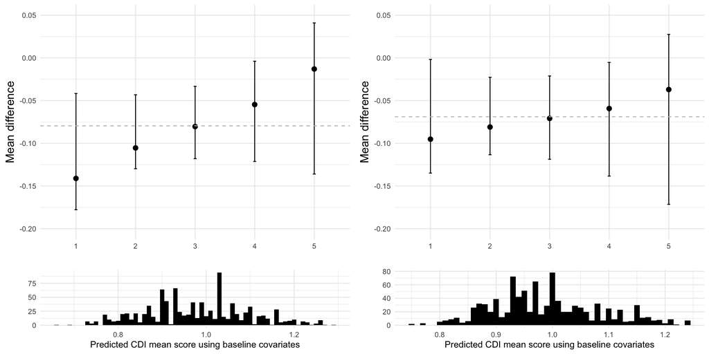

```r
cal_plots <- ggarrange(abc_combo_plot, person_combo_plot, ncol = 2, nrow = 1)
cal_plots
```

```r
ggsave("figures/cal_plots.png", width = 10, height = 7, dpi = 600)
```